# Visualizacion - Texto “El Joven Rey”

Proyecto realizado por:

- *Krissia Bejarano 2023044809*
- *Sebastian Sanchez 2023346349*

## La emociones en el texto literario

Cuando leemos una novela el impacto que esta nos produce depende en gran medida de cómo se presentan y se desarrollan las emociones. Son precisamente las emociones las que logran conectar al lector con la historia, las que lo envuelven y lo motivan a seguir leyendo o, por el contrario, pueden generar desinterés y desconexión.

La literatura tiene la capacidad única de hacernos sentir, y es a través de los sentimientos que nos identificamos con los personajes, comprendemos sus decisiones y compartimos sus vivencias. El sentimiento de empatía, la identificación con los conflictos y dilemas de los personajes, el anhelo o la tensión que despierta el desarrollo de la trama, y las emociones que nos provoca cada situación narrada, son elementos fundamentales que nos atraen y nos impulsan a seguir leyendo. En este sentido, las emociones no solo enriquecen la experiencia literaria, sino que son el puente que une al lector con la obra, haciéndola memorable y profundamente humana.

## El Joven Rey

En esta obra se relata la transformación moral de un joven rey al enfrentarse a las crudas realidades sociales y a las consecuencias del poder, la jerarquización y el lujo desmedido. A través de una serie de visiones o sueños reveladores, el protagonista descubre el sufrimiento humano que se oculta detrás de cada elemento de su coronación: las telas de su vestimenta, las joyas de su corona y los rituales del poder han sido posibles gracias a la esclavitud, la miseria y la injusticia. Conmovido por esta revelación, el joven decide renunciar a los símbolos materiales del poder y opta por coronarse humildemente, vistiendo ropas sencillas y rechazando el boato de la realeza.

De este modo, se enfrenta no solo a la estructura social que sustenta su posición, sino también al desprecio de los nobles y a la incomprensión de quienes esperan que cumpla con las expectativas tradicionales del trono. Su acto es una denuncia silenciosa contra el esplendor artificial de la monarquía, construido sobre el dolor de los más vulnerables. Al final, comprendemos que el verdadero rey no es aquel que ostenta riquezas, sino quien actúa con justicia, compasión y en favor de su pueblo. En recompensa por su integridad, el joven es finalmente coronado por una luz divina, símbolo de una coronación espiritual y moral que trasciende lo terrenal y consagra su transformación interior.

## Metodologia

Decidimos separar nuestro analisis de visualizacion de texto en 3 areas especificas:

- Estudio general del texto, un analisis general de patrones de escritura y de sentimientos en el texto, utilizando *nubes de palabras* y *analisis de frecuencia de emociones*.
- Estudio temporal, donde tomamos los datos obtenidos en el estudio general y buscamos contextualizalo al rededor de como estos sentimientos cambian en el curso de la obra, utilizamos *analisis de polaridad* y *arco emocional*.
- Estudio relacional, utilizamos una red de palabras como informacion adicional para encontrar patrones tematicos en el texto.

## Analisis de Resultados

### Estudio general del texto

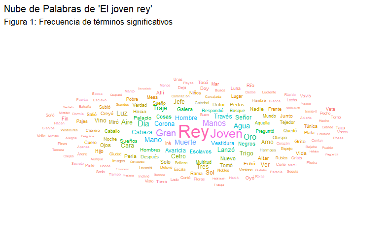

Términos como “vestidura”, “manos” y “traje” también evocan imágenes de trabajo, y se relacionan estrechamente con otras palabras como “sueños”, “dolor”, “muerte” y “esclavos”. Esto sugiere que, en el texto, el trabajo forzado y la esclavitud son temas centrales. Los esclavos, muchas veces condenados por nacer en la pobreza, ven sus sueños arrebatados y enfrentan condiciones de vida marcadas por el sufrimiento, la injusticia y la amenaza constante de la muerte, mientras las élites ejercen su poder sin considerar el costo humano.

Es tambien conveniente visualizar la frecuencia de estas palabras asociadas con ciertos sentimientos a lo largo de todo el texto, por lo que generamos una visualizacion de barras de las emociones utilizando el paquete de analisis textual “syuzhet” del lenguaje R.

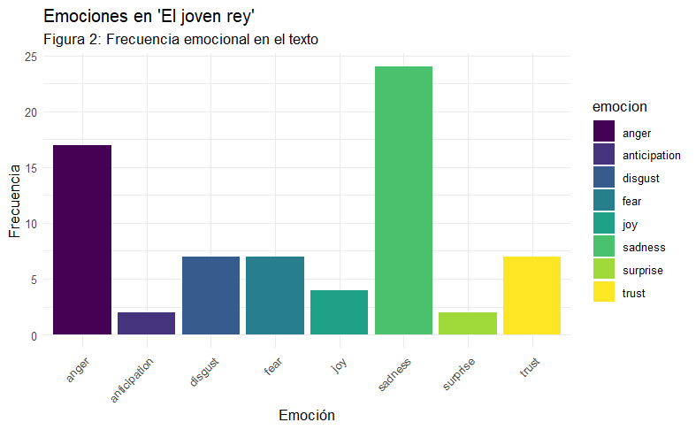

En la *Figura 2* representamos el conteo de emociones presentes en “El joven rey”, según el léxico asociado a distintas categorías emocionales. Las emociones que predominan son la tristeza, la ira, el disgusto y el miedo.

La tristeza es la emoción más frecuente, con una puntuación cercana a 24. Esto sugiere que el texto contiene una gran cantidad de expresiones relacionadas con el dolor, la infelicidad y la compasión. El relato está impregnado de esta emoción, ya que el joven rey descubre la crueldad y el sufrimiento que se ocultan detrás de los lujos que lo rodean. Desde la vestimenta hasta las joyas, todo ha sido elaborado a costa del sufrimiento ajeno. La esclavitud, la miseria y la muerte de los artesanos que confeccionan estos objetos son algunas de las realidades que justifican la alta presencia de esta emoción en el texto.

La ira, la segunda emoción más frecuente, con una puntuación aproximada de 17, se encuentra estrechamente ligada a la tristeza. Refleja sentimientos de frustración, resentimiento y enojo que surgen en diversos momentos de la historia: la indignación del tejedor, la furia del joven rey al verse forzado a cumplir ceremonias vacías, la rabia de la Muerte ante la avaricia humana, y la ira de los nobles al ver al rey vestido como un mendigo, rechazando el lujo y las costumbres que se sostienen sobre el sufrimiento de otros.

El asco (o disgusto), con una frecuencia cercana a 7 términos, evoca sensaciones de repulsión. Esta emoción se asocia principalmente con la reacción de los nobles al ver las condiciones de vida de los pobres, quienes están rodeados de enfermedad, miseria, crueldad y muerte. Desde su posición de poder, los nobles no se ven afectados por estas realidades; las observan con desprecio y repulsión, sin empatía ni responsabilidad.

El miedo, con una frecuencia similar al disgusto, también está presente en la narrativa, especialmente en los sueños del joven rey. Se manifiesta como temor a la muerte, a la esclavitud, al hambre y a la injusticia social. Un ejemplo claro se da cuando el rey comprende el horror y el sufrimiento que se esconden tras sus elegantes vestimentas.

Las emociones menos frecuentes son la sorpresa y la anticipación, con valores muy bajos, alrededor de 2 o menos. Les siguen la alegría y la confianza, con valores entre 3 y 7. Esto revela una marcada predominancia de emociones negativas, especialmente la tristeza y la ira. Además, indica que el texto no genera grandes expectativas ni momentos de asombro repentino.

Esta baja presencia de emociones positivas puede deberse al tono sombrío y reflexivo del cuento, centrado en la revelación de verdades dolorosas más que en una trama llena de giros inesperados. También es comprensible que emociones como la alegría y la confianza aparezcan de forma mínima y superficial, ya que los lujos descritos ofrecen solo un placer momentáneo. Detrás de ellos, hay sufrimiento oculto. Asimismo, el protagonista desconfía de quienes tienen el poder de cambiar estas injusticias, pero eligen no hacer nada al respecto.

### Estudio temporal

Como siguiente paso para el analisis, es conveniente utilizar tecnicas de “Polaridad” que aproximan el valor emocional a lo largo del texto. En relacion con los resultados evidenciados en la *Figura 2* a traves del tiempo, la siguiente visualizacion utiliza el paquete syuzhet. Analizamos oracion por oracion el valor de polaridad (emocion negativa o positiva) y lo presentamos como una grafica de lineas. Asimismo, por propositos de claridad se provee una curva de intervalo de confianza para demostrar el valor promedio aproximado en un area, como una estimacion del sentimiento general al leer varias partes del texto. Finalmente, las oraciones con valores mas intensos emocionalente son resaltadas usando puntos de color **rojo** y **azul** para valores positivos y negativos, respectivamente.

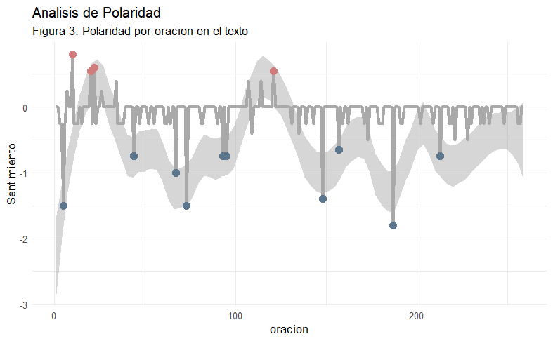

> “Aquella noche, la víspera del día fijado para su coronación, el joven rey se hallaba solo, sentado en su cámara espléndida. Sus cortesanos se habían despedido todos, inclinando la cabeza hasta el suelo, según los usos ceremoniosos de la época, y se habían retirado al gran salón del palacio para recibir las últimas lecciones del profesor de etiqueta, pues aun había entre ellos algunos que tenían modales naturales, lo cual, apenas necesito decirlo, es gravísima falta en cortesanos.”

A pesar de que tambien utiliza palabras mas positivas como “esplendida”, consideramos que esta aproximacion correctamente demuestra la emocion ligeramente melancolica de esta seccion del texto.

Adicionalmente, podemos notar dos “picos” de emocion positiva en el texto, seguidos de “valles” de emocion negativa. Podemos evidenciar estos cambios mas generalmente por medio de la tecnica de “Arco Emocional” del paquete syuzhet, que utiliza transformaciones discretas de cosenos (Discrete Cosine Transformation) para “suavizar” estos cambios en la polaridad en relacion con los datos al rededor del punto, similarmente a la curva de intervalo de confianza utilizada en la *Figura 3*.

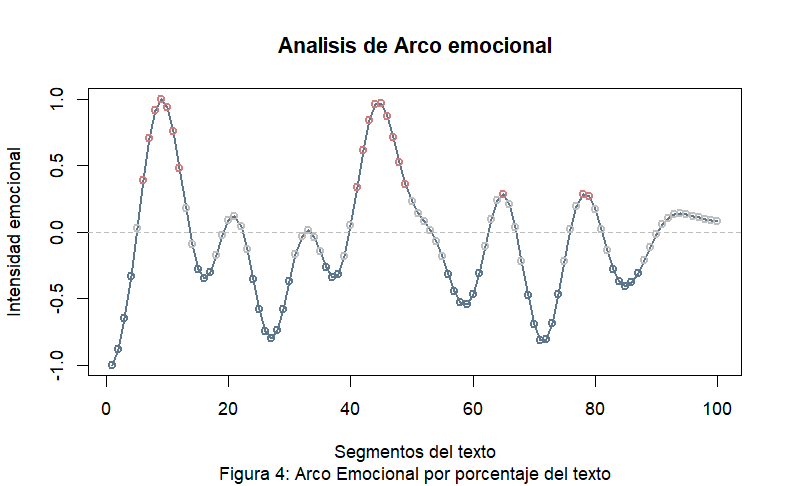

> “El buzo subió por última vez y la perla que trajo era más hermosa que todas las perlas de Ormuz, porque tenía forma de luna llena y era más blanca que la estrella de la mañana.”

> “Creyó que vagaba por un bosque oscuro, lleno de frutos extraños y de lindas flores venenosas.”

## Estudio Relacional

Como ultimo punto de analisis, hacemos uso de la estrategia de “Red de Palabras” utilizando la funcionalidad del paquete “tm” de R. Este grafico nos permite mostrar las palabras mas utilizadas, junto con sus conexiones con otras plabras relevantes.

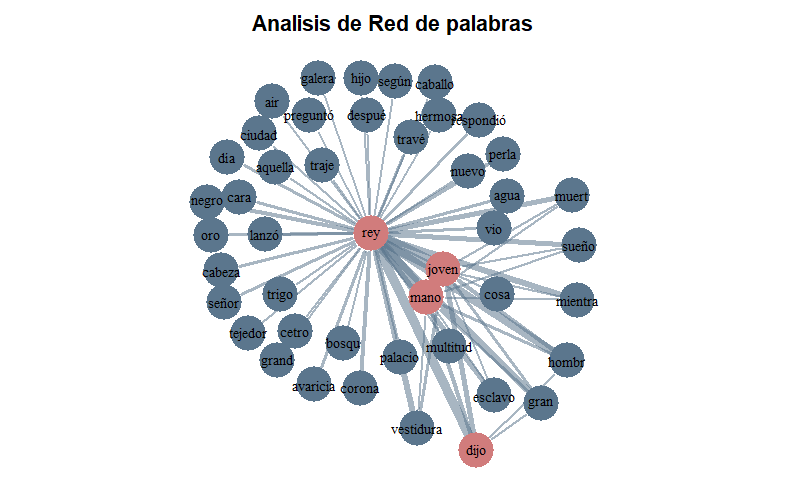

En la *Figura 5*, podemos ver algunas de las palabras mas comunes en el texto, y como reflejan los elementos mas recurrentes en la historia, asimismo, se resaltan las palabras con mayores conexiones en color **rojo**, con otras palabras por proposito de claridad.

Podemos observar algunas palabras que son esperadas de un texto con dialogo, como “dijo”, asi como las palabras “rey” y “joven” siendo conectadas muy fuertemente. Sin embargo, la gran cantidad de conexiones con la palabra “rey” parecen reflejar varios de los elementos en los sueños del Joven Rey, como “perla”, “agua” y “esclavo”.

Asimismo, observamos que las conexiones mas fuertes con el nodo del “rey” son las palabras “muerte”, “sueño”, “vestidura”, “hombre”, y “esclavo”

## Anexos

### Anexos

- Version Web del texto “El Joven Rey”: https://web.seducoahuila.gob.mx/biblioweb/upload/Wilde,%20Oscar%20-%20El%20Joven%20Rey%20(1).pdf
- https://tecdigital.tec.ac.cr/dotlrn/classes/CA/IC8056/S-1-2025.CA.IC8056.1/file-storage/view/Apuntes%2F2022_AnalisisSentimientos.pdf